# ITV methods

Supplementary material

Code author: Facundo X. Palacio

2023-05-15

```r
# Load packages
library(MASS) # Simulating multivariate normal and Wishart distributions
library(ggplot2) # Plotting
library(ggpubr) # Plotting
library(dplyr) # Data handling
library(tidyr) # Data handling
library(knitr) # Improved layout
library(mobsim) # Community matrices simulation
library(lme4) # Linear mixed models
library(boot) # Bootstrap confidence intervals
library(cati) # T-statistics, Rao's entropy decomposition
library(factoextra) # Plot nice dendrograms
library(geometry) # for TOP index (convex hulls)
library(geozoo) # for TED index (spehere random points)
library(flexmix) # for TED index (KL divergence)
library(TPD) # Trait-probability density
library(alphahull) # Convex hulls
library(BAT) # Hypervolumes
```

Set simulation parameters

```r
set.seed(999)

# Number of communities
ncomms <- 15

# Species richness
nsp <- 20

# Number of traits
ntraits <- 3

# Number of individuals sampled per species
nindxsp <- 10
```

# Trait matrix at the individual level

```r
trait_matrix <- list()

for(i in 1:ncomms){
mean_traits <- rnorm(ntraits, mean = 10, sd = 6) # Assume a normal distribution (fixed for every species in the same community)
sigma_traits <- rWishart(1, df = ntraits, Sigma = diag(ntraits)) # Assume a standard Wishart distribution (fixed for every species in the same community)

# Trait matrix per community
trait_ind <- list()

for(j in 1:nsp){
trait_ind[[j]] <- mvrnorm(n = nindxsp, mu = mean_traits, Sigma = sigma_traits[,,1], tol = 1e-6, empirical = FALSE, EISPACK = FALSE)
}
sp_label <- sort(rep(1:nsp, nindxsp))

trait_matrix[[i]] <- as.data.frame(do.call("rbind", trait_ind))
trait_matrix[[i]] <- data.frame(species = sp_label, trait_matrix[[i]])
}
names(trait_matrix) <- 1:ncomms
```

# Community matrix

```r
nind <- 200 # Number of individuals per community
C <- matrix(0, nrow = ncomms, ncol = nsp)
for(i in 1:ncomms){
  C[i, ] <- as.numeric(sim_sad(s_pool = nsp, n_sim = nind,
                              sad_type = "lnorm", sad_coef = list("meanlog" = 5, "sdlog" = 0.5),
                              fix_s_sim = TRUE))
}

colnames(C) <- 1:nsp
rownames(C) <- 1:ncomms
```

# Trait data visualization

As an example, we will base the analysis on community number 5. First, we can explore individual trait distributions and correlations.

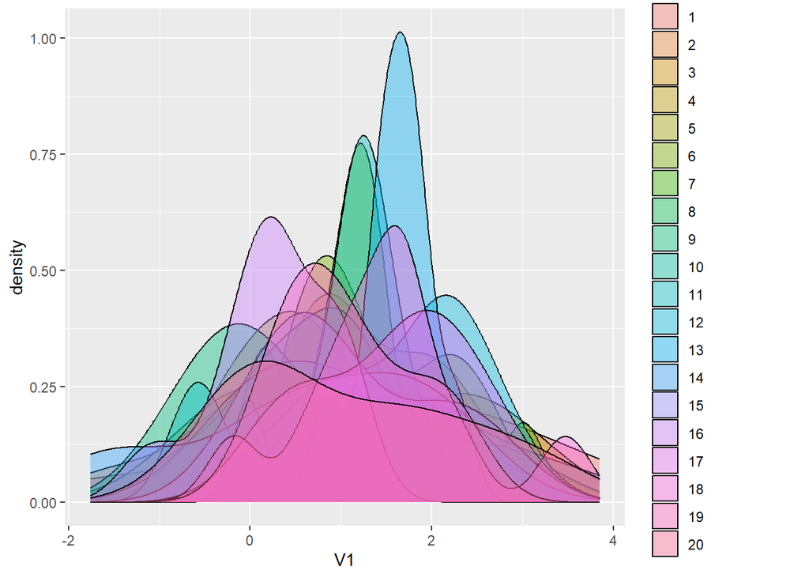

```r
T5 <- trait_matrix[[5]]
ggplot(T5, aes(x = V1, fill = as.factor(species))) + geom_density(alpha = 0.4)
```

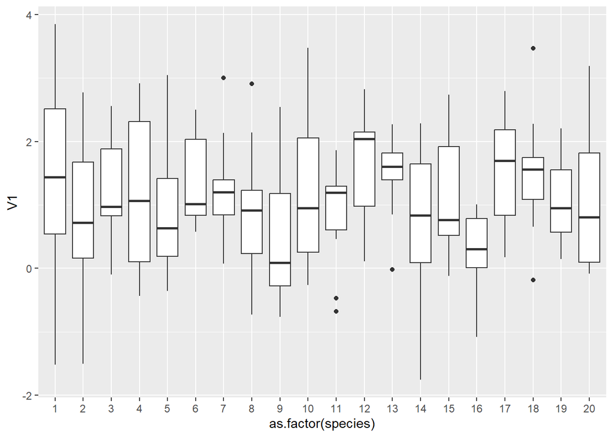

```r
ggplot(T5, aes(x = as.factor(species), y = V1)) + geom_boxplot()
```

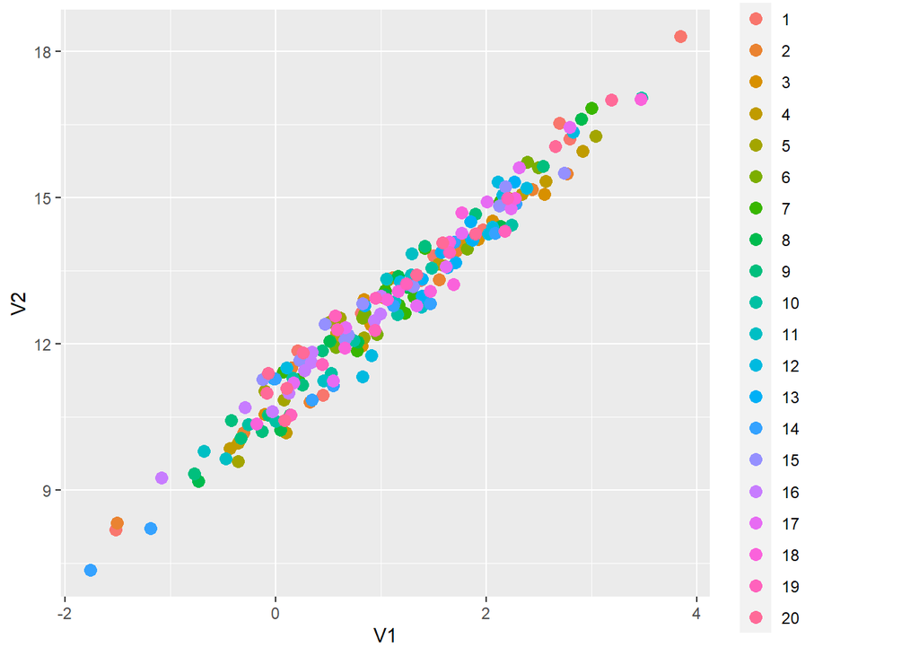

```r
ggplot(T5, aes(x = V1, y = V2, color = as.factor(species))) +
  geom_point(size = 3)
```

# One species, a single trait: the coefficient of variation and the phenotypic dissimilarity index

`uni_cv` computes the coefficient of variation and the Bao’s coefficient of variation for a single (continuous) trait and a set of species.

```r
uni_cv <- function(trait, species){
  species <- as.factor(species)
  sp <- table(species)
  Nsp <- length(sp)
  df <- data.frame(species, trait)
  summary_cv <- as.data.frame(matrix(NA, nrow = Nsp, ncol = 7))
  sp.names <- unique(df$species)

  for(i in 1:Nsp){
    subdata <- subset(df, species == sp.names[i])
    N <- length(subdata$trait)
    meanT <- mean(subdata$trait, na.rm = TRUE)
    S <- sd(subdata$trait, na.rm = TRUE)
    cv <- S/meanT
    skew <- sum(((subdata$trait - meanT)/S)^3)/N
    kurt <- sum(((subdata$trait - meanT)/S)^4)/N
    BaoCV <- cv - cv^3/N + cv/(4*N) + cv^2*skew/(2*N) +
                 cv*kurt/(8*N)
    summary_cv[i, ] <- c(N, meanT, S, cv, skew, kurt, BaoCV)
  }

  summary_cv <- data.frame(sp.names, summary_cv)
  colnames(summary_cv) <- c("Species", "Sample size", "Mean",
                            "Standard deviation", "CV", "Skewness",
                            "Kurtosis", "Bao's CV")
    summary_cv
}

trait <- trait_matrix[[5]]$V1
species <- as.factor(trait_matrix[[5]]$sp)
kable(uni_cv(trait = trait, species = species), digits = 2)
```

| Species | Sample size | Mean | Standard deviation | CV | Skewness | Kurtosis | Bao’s CV |
| --- | --- | --- | --- | --- | --- | --- | --- |
| 1 | 10 | 1.41 | 1.53 | 1.08 | -0.24 | 2.15 | 1.00 |
| 2 | 10 | 0.84 | 1.32 | 1.56 | -0.13 | 1.78 | 1.24 |
| 3 | 10 | 1.24 | 0.81 | 0.65 | 0.09 | 1.70 | 0.66 |
| 4 | 10 | 1.16 | 1.30 | 1.12 | 0.05 | 1.10 | 1.02 |
| 5 | 10 | 0.90 | 1.05 | 1.18 | 0.70 | 2.21 | 1.12 |
| 6 | 10 | 1.37 | 0.75 | 0.54 | 0.40 | 1.24 | 0.56 |
| 7 | 10 | 1.24 | 0.86 | 0.69 | 0.55 | 2.47 | 0.71 |
| 8 | 10 | 0.93 | 1.05 | 1.13 | 0.33 | 2.16 | 1.07 |
| 9 | 10 | 0.48 | 1.10 | 2.27 | 0.65 | 1.81 | 1.38 |
| 10 | 10 | 1.18 | 1.19 | 1.01 | 0.51 | 1.89 | 0.98 |
| 11 | 10 | 0.86 | 0.83 | 0.97 | -0.81 | 2.08 | 0.89 |
| 12 | 10 | 1.66 | 0.85 | 0.51 | -0.41 | 1.70 | 0.52 |
| 13 | 10 | 1.45 | 0.64 | 0.44 | -1.04 | 3.23 | 0.45 |
| 14 | 10 | 0.66 | 1.35 | 2.05 | -0.48 | 1.77 | 1.19 |
| 15 | 10 | 1.11 | 0.95 | 0.85 | 0.42 | 1.58 | 0.84 |
| 16 | 10 | 0.26 | 0.65 | 2.48 | -0.56 | 2.37 | 0.92 |
| 17 | 10 | 1.55 | 0.86 | 0.55 | -0.23 | 1.53 | 0.56 |
| 18 | 10 | 1.50 | 0.97 | 0.65 | 0.28 | 2.71 | 0.66 |
| 19 | 10 | 1.09 | 0.72 | 0.66 | 0.39 | 1.56 | 0.67 |
| 20 | 10 | 1.10 | 1.21 | 1.10 | 0.44 | 1.48 | 1.04 |

Looking at trait distributions, it seems that species do not strongly vary between them, but there is high variability within the same species.

`PhD` computes the phenotypic dissimilarity (PhD) index, which allows quantifying intraspecific trait variability between populations or groups of individuals growing in different environmental conditions while considering the effect of phenotypic variability within populations. To give an example, we will consider that there are two extremes of an environmental gradient (A and B) and will assign individuals of each species to each of these two treatments. Within each species, the lowest values belong to treatment A, and the highest, to treatment B.

```r
PhD <- function(groups, dis){
  Ngroups <- length(unique(groups))
  raoWithin <- numeric(Ngroups)
  raoBetween <- numeric((Ngroups^2-Ngroups)/2)
  PhD <- numeric((Ngroups^2-Ngroups)/2)
  for(i in 1:Ngroups){
    groupAux<-which(groups == unique(groups)[i])
     disAux <- dis[groupAux, groupAux]
    raoWithin[i]<- sum(disAux)/length(disAux)
    names(raoWithin)[i] <- unique(groups)[i]
  }
  index<-1
  for(i in 1:Ngroups){
    groupAuxi<-which(groups == unique(groups)[i])
    Groupi<-unique(groups)[i]
    for(j in 1:Ngroups){
      if(j>i){
        groupAuxj<-which(groups == unique(groups)[j])
        Groupj<-unique(groups)[j]
        disAux <- dis[groupAuxi, groupAuxj]
        raoBetween[index]<-sum(disAux)/length(disAux)
        names(raoBetween)[index] <- paste0(Groupi, "-", Groupj)

        PhD[index] <- (raoBetween[index] - 0.5*raoWithin[i] - 0.5*raoWithin[j])/
          (1 - 0.5*raoWithin[i] - 0.5*raoWithin[j])
        names(PhD)[index] <- paste0(Groupi, "-", Groupj)
        index<-index+1

      }
    }
  }
  meanPhD <- mean(PhD)
  return(list(PhD = PhD, meanPhD = meanPhD))
}

T5 <- T5 %>% group_by(species) %>% arrange(V1, .by_group = TRUE) %>% as.data.frame
T5$treatment <- rep(rep(c("A", "B"), each = 5), 20)

PhD_index <- c(); CV_A <- c(); CV_B <- c()
species_names <- unique(T5$species)

for(i in 1:length(species_names)){
  subtraits <- subset(T5, species == species_names[i])
  dissim.matrix <- as.matrix(dist(subtraits$V1))
  dissim.matrix <- dissim.matrix/max(dissim.matrix) # bound between 0 and 1
  PhD_index[i] <- PhD(groups = subtraits$treatment, dis = dissim.matrix)[[1]]
  CV <- tapply(subtraits$V1, subtraits$treatment, function(x) sd(x, na.rm = TRUE)/mean(x, na.rm = TRUE))
  CV_A[i] <- CV[1]
  CV_B[i] <- CV[2]
}

df_PhD_index <- data.frame(species = species_names, PhD_index, CV_A, CV_B)
kable(df_PhD_index, digits = 2)
```

| species | PhD_index | CV_A | CV_B |
| --- | --- | --- | --- |
| 1 | 0.30 | 4.07 | 0.35 |
| 2 | 0.41 | -3.24 | 0.35 |
| 3 | 0.37 | 0.69 | 0.30 |
| 4 | 0.64 | 150.52 | 0.22 |
| 5 | 0.30 | 2.75 | 0.59 |
| 6 | 0.54 | 0.20 | 0.29 |
| 7 | 0.25 | 0.75 | 0.41 |
| 8 | 0.30 | 3.82 | 0.47 |
| 9 | 0.39 | -0.81 | 0.74 |
| 10 | 0.40 | 1.72 | 0.42 |
| 11 | 0.30 | 2.80 | 0.18 |
| 12 | 0.37 | 0.69 | 0.14 |
| 13 | 0.22 | 0.63 | 0.13 |
| 14 | 0.43 | -2.46 | 0.27 |
| 15 | 0.39 | 0.88 | 0.41 |
| 16 | 0.31 | -2.66 | 0.48 |
| 17 | 0.41 | 0.68 | 0.17 |
| 18 | 0.23 | 0.77 | 0.35 |
| 19 | 0.42 | 0.54 | 0.34 |
| 20 | 0.58 | 2.41 | 0.36 |

# One species, multiple traits: the multivariate coefficient of variation

`multi_cv` computes the multiple coefficient of variation for a set of traits and species.

```r
multi_cv <- function(traits, species){
  species <- as.factor(species)
  p <- ncol(traits)
  mu <- colMeans(traits, na.rm = TRUE)
  sigma <- as.matrix(var(traits, na.rm = TRUE))
  trace <- sum(diag(sigma))
  R <- sqrt((det(sigma)^(1/p))/(t(mu) %*% mu)) # Reyment's CV
  VV <- sqrt(trace/(t(mu) %*% mu)) # Van Valen's CV
  VN <- sqrt(1/(t(mu) %*% solve(sigma) %*% mu)) # Voinoi and Nikulin's CV
  AZ <- sqrt((t(mu) %*% sigma %*% mu)/((t(mu) %*% mu)^2)) # Albert and Zhang's CV
  cvs <- data.frame(R, VV, VN, AZ)
  colnames(cvs) <- c("Reyment", "Van Valen", "Voinoi and Nikulin", "Albert and Zhang")
  cvs
}
species <- as.factor(trait_matrix[[5]]$sp)
traits <- trait_matrix[[5]][,-1]

kable(multi_cv(species = species, traits = traits), digits = 2)
```

| Reyment | Van Valen | Voinoi and Nikulin | Albert and Zhang |
| --- | --- | --- | --- |
| 0.03 | 0.12 | 0.02 | 0.08 |

Note how variability considering multiple correlated traits strongly reduced compared to single trait variability.

# Multiple species, a single trait: community-weighted variance and variance partitioning

## Community weighted intraspecific trait variance

`CWmetrics` computes the community-weighted mean (CWM), variance (CWV) and intraspecific variance (CWIV) for a set of communities and traits. The function needs a community data frame (argument `comm`) and a list of individuals x trait data frames (argument `traits`). The first column of each data frame must contain the species label (argument `species`). If intraspecific variability is 0, then CWIV = CWV. This happens when one is working under the mean field approach (the trait matrix is composed of mean trait values). The outuput is a data frame with CWM, CWV and CWIV for each community and trait.

```r
CWmetrics <- function(comm, traits, species, S = 0){
# Trait matrix at the species level (mean field approach)
df_traits <- do.call("rbind", traits)
df_traits$species <- as.factor(df_traits$species)
meanT <- df_traits %>% group_by(species) %>%
  summarise(across(where(is.numeric), ~ mean(.x, na.rm = TRUE))) %>%
  as.data.frame()
sdT <- df_traits %>% group_by(species) %>%
  summarise(across(where(is.numeric), ~ sd(.x, na.rm = TRUE))) %>%
  as.data.frame()
t <- as.matrix(meanT[, -1]) # trait means
S <- as.matrix(sdT[, -1]) # trait standard deviations

# Community-weighted metrics
R <- as.matrix(comm/rowSums(comm))  # Species relative abundances
# Community-weighted mean
CWM <- R %*% t
colnames(CWM) <- paste0("CWM", 1:ncol(t))
# Community-weighted variance
CWV <- (R %*% t^2) - CWM^2
colnames(CWV) <- paste0("CWV", 1:ncol(t))
# Community-weighted intraspecific variance
CWIV <- (R %*% (t^2 + S^2)) - CWM^2
colnames(CWIV) <- paste0("CWIV", 1:ncol(t))

CW <- data.frame(CWM, CWV, CWIV)
CW
}

kable(CWmetrics(comm = C, traits = trait_matrix, species = sp), digits = 2)
```

| CWM1 | CWM2 | CWM3 | CWV1 | CWV2 | CWV3 | CWIV1 | CWIV2 | CWIV3 |
| --- | --- | --- | --- | --- | --- | --- | --- | --- |
| 8.91 | 7.06 | 9.91 | 0.03 | 0.01 | 0.03 | 18.90 | 26.65 | 39.92 |
| 8.93 | 7.05 | 9.87 | 0.03 | 0.01 | 0.02 | 19.07 | 26.69 | 40.02 |
| 8.91 | 7.05 | 9.89 | 0.03 | 0.01 | 0.02 | 18.96 | 26.72 | 39.78 |
| 8.91 | 7.05 | 9.86 | 0.03 | 0.01 | 0.03 | 19.05 | 26.73 | 39.66 |
| 8.90 | 7.06 | 9.89 | 0.03 | 0.01 | 0.03 | 19.09 | 26.78 | 39.87 |
| 8.90 | 7.06 | 9.90 | 0.03 | 0.01 | 0.02 | 19.01 | 26.52 | 39.80 |
| 8.92 | 7.06 | 9.89 | 0.03 | 0.01 | 0.02 | 18.94 | 26.50 | 39.93 |
| 8.89 | 7.06 | 9.89 | 0.03 | 0.01 | 0.02 | 18.86 | 26.78 | 39.72 |
| 8.92 | 7.05 | 9.90 | 0.02 | 0.01 | 0.02 | 18.67 | 26.58 | 40.17 |
| 8.91 | 7.05 | 9.90 | 0.03 | 0.01 | 0.03 | 19.02 | 26.65 | 39.89 |
| 8.88 | 7.06 | 9.93 | 0.03 | 0.01 | 0.02 | 18.75 | 26.64 | 39.99 |
| 8.93 | 7.05 | 9.91 | 0.03 | 0.01 | 0.02 | 18.72 | 26.89 | 40.26 |
| 8.91 | 7.06 | 9.92 | 0.04 | 0.01 | 0.02 | 18.79 | 26.65 | 39.84 |
| 8.88 | 7.05 | 9.92 | 0.03 | 0.01 | 0.02 | 18.85 | 26.54 | 39.86 |
| 8.90 | 7.06 | 9.92 | 0.03 | 0.00 | 0.03 | 18.77 | 26.87 | 40.15 |

For this particular case, this reveals that not accounting for ITV largely underestimates functional diversity. This is because intraspecific variability is much more larger than interspecific variance.

## Linear mixed models

Linear mixed models allow to disentangle the sources of variation between and within-levels of a factor (species), so that we can estimate the contribution of interspecific and intraspecific trait variability. In addition, we can compute confidence intervals for each component based on bootstrap replicates.

```r
dataV1 <- data.frame(species = as.factor(species), trait)
var_comps_V1 <- lmer(trait ~ 1|species, REML = TRUE, data = dataV1)
vc <- VarCorr(var_comps_V1)
varcomps1 <- c(unlist(lapply(vc, diag)), attr(vc, "sc")^2)
varcomps1 <- as.data.frame(t(100*(varcomps1/sum(varcomps1))))
colnames(varcomps1) <- c("Between-species variation (%)", "Within-species variation (%)")
kable(varcomps1, digits = 2)
```

| Between-species variation (%) | Within-species variation (%) |
| --- | --- |
| 2.35 | 97.65 |

```r
var.comp <- function(df, d){
  newdf <- df[d, ]
  model <- lmer(trait ~ 1|species, REML = TRUE, data = newdf)
  vcorr <- VarCorr(model)
  vc <- c(unlist(lapply(vcorr,diag)), attr(vcorr,"sc")^2)
  percn <- round(100*(vc/sum(vc)),3)
  percn
}

b <- boot::boot(dataV1, var.comp, R = 1000)
b
```

```
##
## ORDINARY NONPARAMETRIC BOOTSTRAP
##
##
## Call:
## boot::boot(data = dataV1, statistic = var.comp, R = 1000)
##
##
## Bootstrap Statistics :
##     original   bias    std. error
## t1*    2.348  10.0176    5.164898
## t2*   97.652 -10.0176    5.164898
```

```r
boot.ci(b, conf = 0.95, type = "bca", index = 1)
```

```
## BOOTSTRAP CONFIDENCE INTERVAL CALCULATIONS
## Based on 1000 bootstrap replicates
##
## CALL :
## boot.ci(boot.out = b, conf = 0.95, type = "bca", index = 1)
##
## Intervals :
## Level       BCa
## 95%   ( 0.000,  1.891 )
## Calculations and Intervals on Original Scale
## Warning : BCa Intervals used Extreme Quantiles
## Some BCa intervals may be unstable
```

```r
boot.ci(b, conf = 0.95, type = "bca", index = 2)
```

```
## BOOTSTRAP CONFIDENCE INTERVAL CALCULATIONS
## Based on 1000 bootstrap replicates
##
## CALL :
## boot.ci(boot.out = b, conf = 0.95, type = "bca", index = 2)
##
## Intervals :
## Level       BCa
## 95%   ( 98.11, 100.00 )
## Calculations and Intervals on Original Scale
## Warning : BCa Intervals used Extreme Quantiles
## Some BCa intervals may be unstable
```

As we saw above, there is substantially more trait variation within than between species for this particular community. We can certainly expand this model to account for variation between and within different communities (or any other organizational level) by including additional random effects.

## T-statistics

Based on competition theory, T-statistics dissect the effects of assembly processes by using trait values of individuals. As a result, T-statistics estimate the magnitude of external and environmental filtering based on ITV, through a set of variance ratios ($T_{IP/IC}$, $T_{IC/IR}$ and $T_{PC/PR}$). For each trait V1, V2 and V3 We can also test for the departure of observed trait distributions from null expectations of each of these ratios.

```r
# Trait matrix of individuals
traits <- do.call(rbind, trait_matrix)[,-1]
# Define the name of the species each individual belongs to
species <- as.factor(do.call(rbind, trait_matrix)$sp)
# Define the name of the community each individual belongs to
ind.plot_list <- Map(cbind, trait_matrix, community = names(trait_matrix))
ind.plot <- as.factor(do.call(rbind, ind.plot_list)$community)

T_stats <- Tstats(traits = traits, ind.plot = ind.plot, sp = species, nperm = 500)
```

```
## [1] "creating null models"
## [1] "11.11 %"
## [1] "22.22 %"
## [1] "33.33 %"
## [1] "44.41 %"
## [1] "55.52 %"
## [1] "66.63 %"
## [1] "77.71 %"
## [1] "88.82 %"
## [1] "99.93 %"
## [1] "calculation of Tstats using null models"
## [1] "11.11 %"
## [1] "22.22 %"
## [1] "33.33 %"
## [1] "44.41 %"
## [1] "55.52 %"
## [1] "66.63 %"
## [1] "77.71 %"
## [1] "88.82 %"
## [1] "99.93 %"
```

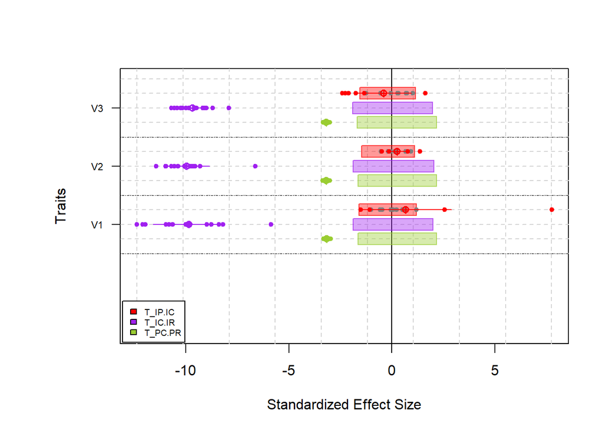

```r
plot(T_stats)
```

The crossed circle and line represent the observed standardized effect size (SES) and the standard deviation, respectively, for a trait and set of communities. Filled circles represent the observed SES for each community, and boxes depict the null distribution. If the line does not overlap with the box, then the null hypothesis is rejected, i.e., there is significant internal or external filtering. $T_{IP/IC}$ measures the strength of internal filtering (niche packing among species); the higher the overlap of ITV, the higher the value $T_{IP/IC}$. For the three traits, two individuals belonging to the same population, do not show more similar trait values than two individuals drawn randomly from the same community. This is evidence for no internal filtering. $T_{IC/IR}$ measures the degree of external filtering when accounting for ITV; the higher the overlap of community trait distributions, the higher the value of $T_{IC/IR}$. $T_{PC/PR}$ measures the degree of external filtering not accounting for ITV (at the species level). Here, $T_{IC/IR}$ and $T_{PC/PR}$ are lower than expected by chance, suggesting that two individuals of the same community have significantly more similar trait values than two individuals randomly drawn from the species pool. This can be interpreted as external filtering for these traits, potentially due to environmental constraints.

# Methods to account for intraspecific trait variability in functional diversity

## Dendrogram-based functional diversity

Some classical approaches in functional diversity, such as the functional dendrogram, have been adapted to account for ITV by building a dendrogram on an individual by trait matrix.

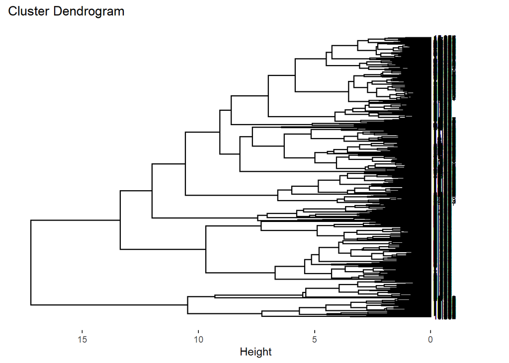

```r
dist_T <- dist(traits) # Euclidean distance, but modify accordingly
func_dendro <- hclust(dist_T, method = "average") # UPGMA
fviz_dend(func_dendro, cex = 0.5, horiz = TRUE)
```

Functional diversity is computed as the sum of the branch lengths connecting those individuals present in the same community. One of the main caveats of the functional dendrogram is that it ignores species abundances when working at the species level, so that two communities with the same species have exactly the same functional diversity value. However, since here the lowest level is represented by individuals, it does not represents a problem for functional diversity estimation, although it only reflects one metric of diversity (functional richness). Functional dendrograms also map categorical traits poorly (not this case).

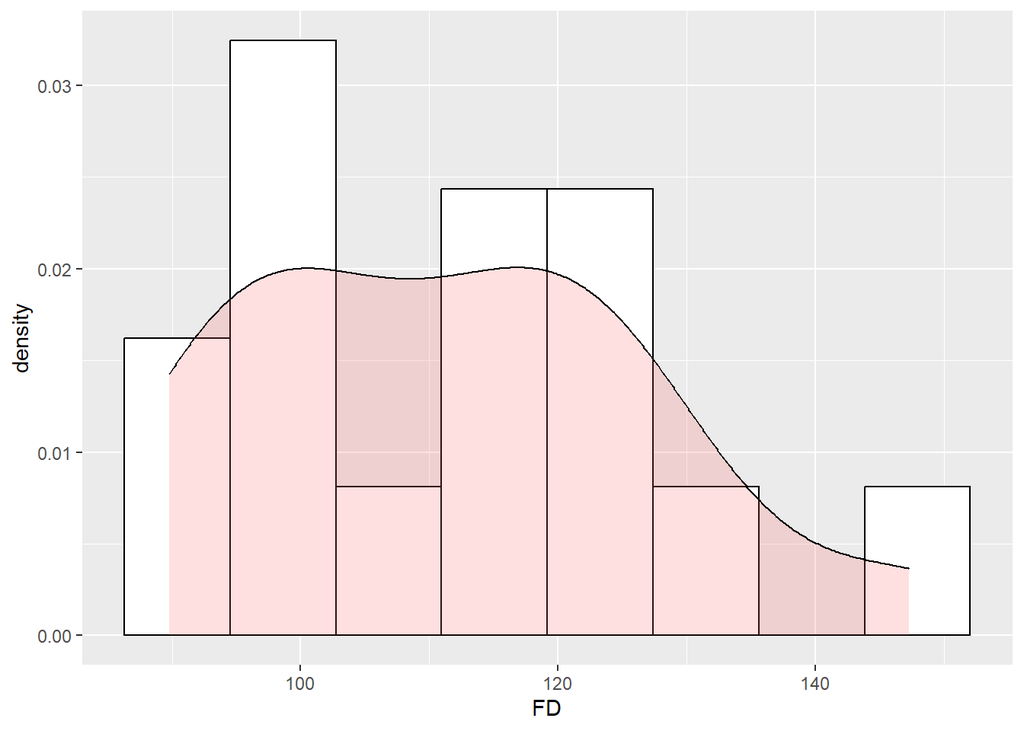

```r
dendroFD <- c()
for(i in 1:ncomms){
Tk <- trait_matrix[[i]][, -1] # Remove first column with species labels
dendroFD[i] <- SumBL(Tk, gower.dist = FALSE, method.hclust = "average", scale.tr = TRUE, method.dist = "euclidian")
}

ggplot(data = data.frame(FD = dendroFD), aes(x = FD)) +
  geom_histogram(aes(y = ..density..), bins = 8, colour = "black", fill = "white") +
  geom_density(alpha = 0.2, fill = "#FF6666")
```

## Variance partitioning and functional diversity

Bello et al. (2011) proposed a method to partition FD into within- and between-species FD. Unlike the methods above, now we can identify the relative contribution of interspecific and intraspecific trait variability to functional diversity.

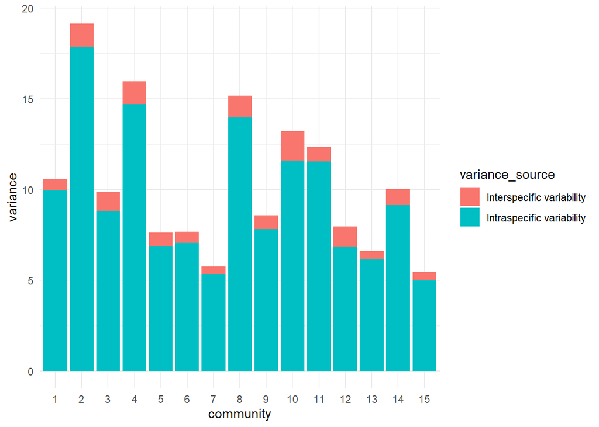

```r
itvFD <- as.data.frame(matrix(0, nrow = ncomms, ncol = 3))
for(k in 1:ncomms){
# First, we create a functional distance matrix at the individual level for each community
Tk <- trait_matrix[[k]][, -1] # Remove first column with species labels
Ck <- C[k, ]
dk <- (as.matrix(dist(Tk))^2)/2

# Second, we create an individual x species matrix for each community
comm <- NULL
for(i in 1:nsp){
 comm[[i]] <- rep(Ck[i], nindxsp)
}
longC <- data.frame(sp = sort(rep(1:nsp, nindxsp)), abun = unlist(comm))

comm <- matrix(0, nrow = nindxsp*nsp, ncol = nsp)
for(j in 1:nsp){
for(i in 1:nrow(longC)){
 comm[i, j] <- ifelse(longC$sp[i] == j, longC$abun[i], 0)
 }
}
class(comm) <- "matrix"

# We now can compute FD accounting for ITV
ITVRao <- RaoRel(sample = comm, dfunc = dk, dphyl = NULL, weight = TRUE, Jost = FALSE, structure = NULL)

# Within species variance
witRao <- ITVRao$FD$Mean_Alpha

# Between species variance
betRao <- ITVRao$FD$Beta_add

# Total variance
totRao <- witRao + betRao

itvFD[k, ] <- c(witRao, betRao, totRao)
}
colnames(itvFD) <- c("Intraspecific variability", "Interspecific variability", "Total variability")

# Barplot
itvFD_long <- gather(data = itvFD[,- 3], key = variance_source, value = variance)
itvFD_long$community <- factor(rep(1:ncomms, 2))
ggplot(data = itvFD_long, aes(x = community, y = variance, fill = variance_source)) +
  geom_bar(stat = "identity") + theme_minimal()
```

In agreement with previous approaches, we see that for each community, intraspecific variability contributes much more to functional diversity than interspecific differences. The great benefit of this approach relative to those above, is that we now can assess the contribution of species turnover (and its covariation with ITV) that may be influencing trait variability. In this particular case, however, it does not make too much sense to dissect turnover from ITV, because we have simulated communities with the same species richness and similar abundances per species across communities. We can perform the analysis for illustrative purposes though.

```r
var_decomp <- decompCTRE(traits = traits, sp = species, ind.plot = ind.plot, print = FALSE)
var_decomp
```

```
## $V1
##
##  Decomposing trait sum of squares into composition turnover
##  effect, intraspecific trait variability, and their covariation:
##         Turnover Intraspec. Covariation  Total
## Total 4.4176e-29     230.71           0 230.71
##
##  Relative contributions:
##        Turnover Intraspec. Covariation Total
## Total 1.915e-31          1           0     1
##
## $V2
##
##  Decomposing trait sum of squares into composition turnover
##  effect, intraspecific trait variability, and their covariation:
##         Turnover Intraspec. Covariation  Total
## Total 4.4176e-29     349.68           0 349.68
##
##  Relative contributions:
##        Turnover Intraspec. Covariation Total
## Total 1.263e-31          1           0     1
##
## $V3
##
##  Decomposing trait sum of squares into composition turnover
##  effect, intraspecific trait variability, and their covariation:
##         Turnover Intraspec. Covariation Total
## Total 4.4176e-29      538.5 -1.1369e-13 538.5
##
##  Relative contributions:
##        Turnover Intraspec. Covariation Total
## Total 8.203e-32          1  -2.111e-16     1
##
## $traits
## [1] "V1" "V2" "V3"
##
## attr(,"class")
## [1] "decompCTRE"
```

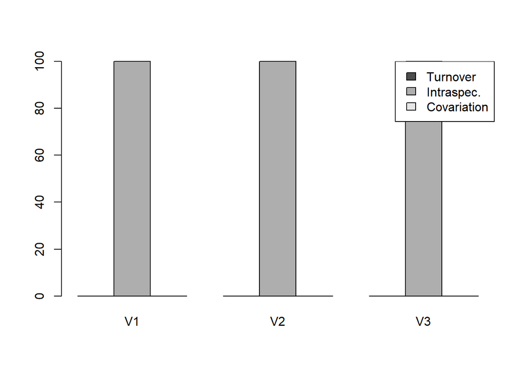

```r
barplot(var_decomp)
```

## Trait onion peeling and trait even distribution

Fontana et al. (2015) developed two indices to account for individual-level trait richness (TOP = Trait onion peeling) and regularity (TED = trait evenness distribution). TOP computes the sum of all successive convex hull areas touching all individuals within a multidimensional trait space. TED is calculated by comparing the probability distributions of pairwise distances between individuals and between points of a perfectly even distribution.

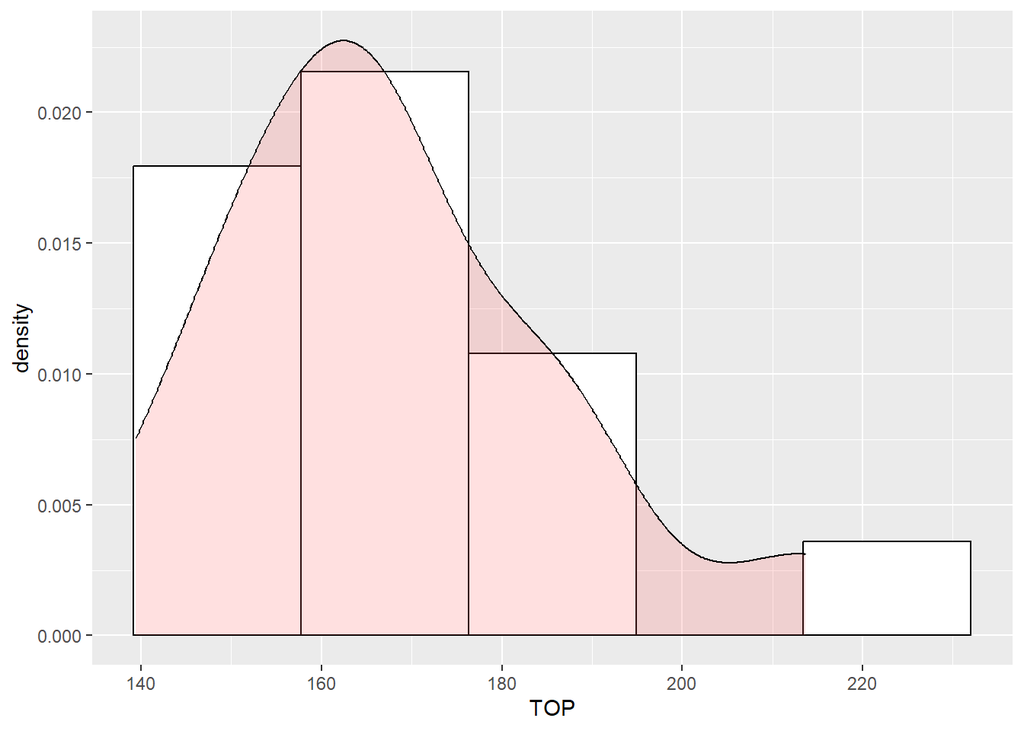

```r
#### Function to compute TOP index (from Fontana et al. 2015)
TOP.index <- function(traitdat){
  # TOP
  dim1 <- ncol(traitdat)
  #definitions: index i, area as empty vector
  i=0
  area<-matrix(ncol=2,nrow=nrow(traitdat))
  while(nrow(traitdat)>dim1){
    i=i+1
    # use of convhulln function
    # area
    area[i,2] <- convhulln(traitdat,"FA")$area
    # identity of vertices
    vert0<-convhulln(traitdat,"Fx TO 'vert.txt'")
    vert1<-scan("vert.txt",quiet=T)
    vert2<-vert1+1

    vertices <- vert2[-1]

    traitdat <- traitdat[-vertices,]

    area[i,1] <- length(vertices)

  }
  area<-na.omit(area)
  # Output (2 numbers): Number of points touched by areas; Sum of the areas (TOP index)
  colSums(area)
}

#### Function to compute TED index (from Fontana et al. 2015)
# List of possible REFERENCES
# Define maximum number of points (max1) and number of traits under consideration (dim1)
# Alternatively, it is possible to manually define max1 and dim1!!
max1 <- nind
dim1 <- ntraits

ref.matrix<-matrix(ncol=2,nrow=max1)
if (dim1 == 1) {
  i=0.9 } else { i=1.9 }
n <- 0
rows1<-0

while(rows1<max1){
  i=i+0.1
  n=n+1
  traits.ref <- sphere.solid.grid(p=dim1, n=i)
  rows1<-nrow(traits.ref$points)
  ref.matrix[n,1]<-i
  ref.matrix[n,2]<-rows1

}

k <- i+1
while(i<k){
  i=i+0.1
  n=n+1
  traits.ref <- sphere.solid.grid(p=dim1, n=i)
  rows1<-nrow(traits.ref$points)
  ref.matrix[n,1]<-i
  ref.matrix[n,2]<-rows1
}

ref.matrix<-na.omit(ref.matrix)

# TED index calculation
TED.index <- function(traitdat){
# Find the best REFERENCE (minimum number of individuals >= individuals in the sample)
  n.sample<-nrow(traitdat)
  diff1<-matrix(ncol=2,nrow=length(ref.matrix)/2)
  diff1[,1] <- ref.matrix[,1]
  diff1[,2] <- ref.matrix[,2]-n.sample
  min.diff1<-min(diff1[,2][diff1[,2]>=0])
  select.i<-diff1[diff1[,2]==min.diff1,][1]
  traits.ref <- sphere.solid.grid(p=dim1, n=select.i)

# Transform REFERENCE in data frame
  traits.ref <- as.vector(traits.ref$points)
  ind<-length(traits.ref)/dim1
  reference<-matrix(ncol=dim1,nrow=ind)
  for (j in 1:dim1){
    reference[,j] <- traits.ref[((j-1)*ind+1):(j*ind)]
  }
  traits.ref <- as.data.frame(reference)

# Ev. delete individuals in order to have the same number as in the sample
  x <- nrow(traits.ref)-nrow(traitdat)

  if (x!=0){

    # coordinates of the center of gravity of the vertices (Gv)
    baryv<-apply(traits.ref,2,mean)

    # euclidian dstances to Gv (dB)
    distbaryv<-rep(0,nrow(traits.ref))
    for (j in 1:nrow(traits.ref))
      distbaryv[j]<-( sum((traits.ref[j,]-baryv)^2) )^0.5

    merge1<-data.frame(traits.ref,distbaryv)

    #sort by distbaryv (descending)
    sort1 <- merge1[order(-distbaryv),]
    traits.ref<-sort1[-1:-x,-(ncol(sort1))]

  }

  # Compare with sample
  Distance.method <- "euclidean"
  D1 <- dist(traitdat, method=Distance.method)
  density.D <- density(D1)$y
  rm(D1)
  D.ref <- dist(traits.ref, method=Distance.method)
  density.D.ref <- density(D.ref)$y
  rm(D.ref)

  results <- KLdiv(cbind(density.D, density.D.ref))

  value <- results[1,2]

  TED <- 1-log10(value+1)
  TED

}


# Compute TOP and TED for every community
TOP_comms <- c()
TED_comms <- c()
for(i in 1:ncomms){
  ztrait_matrix <- as.data.frame(scale(trait_matrix[[i]][, -1])) # recommended to standardize traits
  TOP_comms[i] <- TOP.index(ztrait_matrix)[2]
  TED_comms[i] <- TED.index(ztrait_matrix)
}

TOP_TED <- data.frame(TOP = TOP_comms, TED = TED_comms)
ggplot(data = TOP_TED, aes(x = TOP)) +
  geom_histogram(aes(y = ..density..), bins = 5, colour = "black", fill = "white") +
  geom_density(alpha = 0.2, fill = "#FF6666")
```

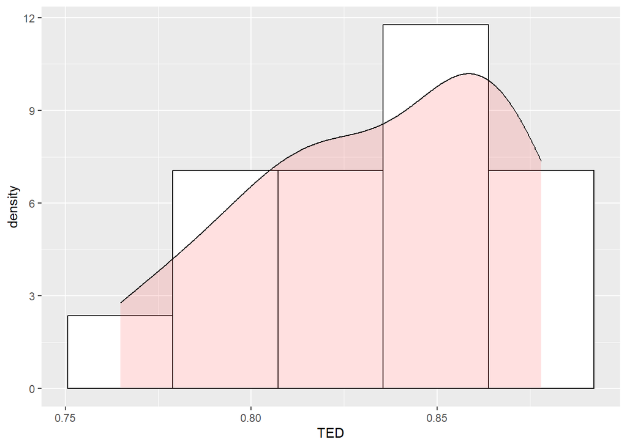

```r
ggplot(data = TOP_TED, aes(x = TED)) +
  geom_histogram(aes(y = ..density..), bins = 5, colour = "black", fill = "white") +
  geom_density(alpha = 0.2, fill = "#FF6666")
```

TOP is more sensitive to the loss of individuals at the edges the distribution, like other functional richness metrics, but also considers changes in the middle of the cloud of data points. We therefore can compare TOP with, for instance, dendrogram-based FD.

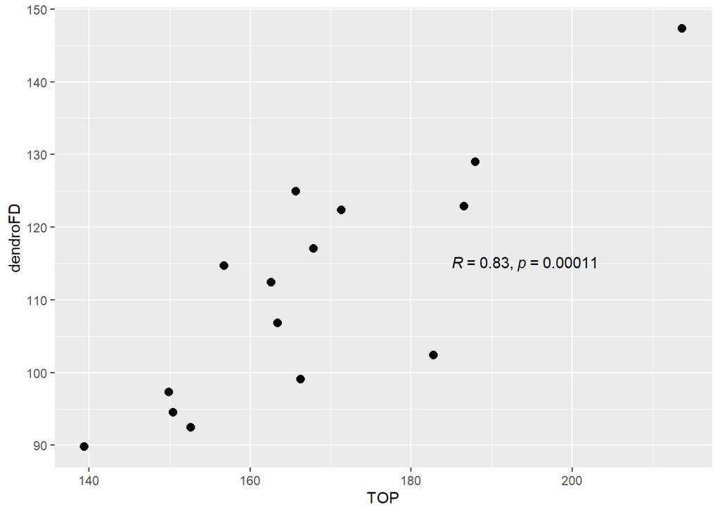

```r
ggplot(data.frame(TOP = TOP_TED$TOP, dendroFD), aes(x = TOP, y = dendroFD)) +
  geom_point(size = 2.5) + stat_cor(method = "pearson", label.x = 185, label.y = 115)
```

In this particular case, both are highly correlated as expected, since trait distributions were simulated under a pure random process.

## Trait-probability density functions

Carmona et al. (2016) developed a framework to account for the probabilistic nature of functional traits. Basically, functional traits are now conceived as trait probability density (TPD) functions (already used in Single trait data visualization, in which each data is represented by an individual, and thus very useful to account for ITV in FD. The TPD of each species (TPDs) are then combined for a given community and weighted for its abundance to compute a TPD for the community (TPDc).

We can first compute 2-dimensional TPDs for species in a given community (e.g., species 1-3, traits V1-V2 in community 5-6).

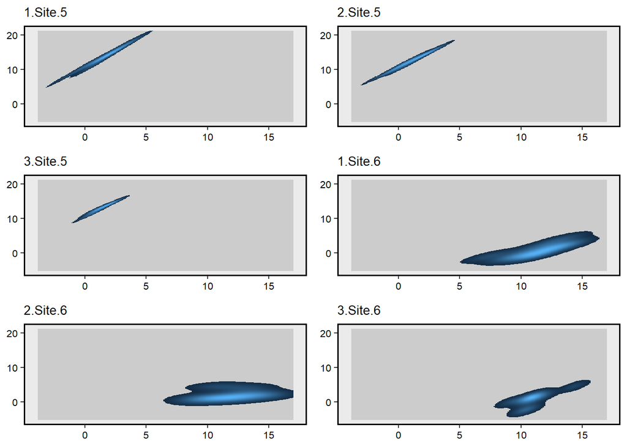

```r
sp135_lab <- trait_matrix[[5]]$species[1:30]
sp135_traits <- trait_matrix[[5]][1:30, 2:3]
sp136_lab <- trait_matrix[[6]]$species[1:30]
sp136_traits <- trait_matrix[[6]][1:30, 2:3]
sp56 <- c(sp135_lab, sp136_lab)
traits56 <- rbind(sp135_traits, sp136_traits)
comm56 <- c(rep("Site.5", 30), rep("Site.6", 30))
TPDs_13_56 <- TPDs(species = sp56, traits = traits56, sample = comm56)
plotTPD(TPD = TPDs_13_56, nRowCol = c(3, 2))
```

We can then compute the TPD of each species and weight them for species relative abundances to compute TPDc for each site.

```r
# Trait matrix of individuals
traits <- do.call(rbind, trait_matrix)[,-1]

# Define the name of the species each individual belongs to
species <- as.factor(do.call(rbind, trait_matrix)$sp)

# Define the name of the community each individual belongs to
ind.plot_list <- Map(cbind, trait_matrix, community = names(trait_matrix))
ind.plot <- as.factor(do.call(rbind, ind.plot_list)$community)

# Compute TPDs and TPDc
TPDs_spp <- TPDs(species = species, traits = traits[, 1:2], samples = ind.plot)
TPDc_comm <- TPDc(TPDs = TPDs_spp, sampUnit = C)

# Compute FD
TPD_FD <- REND(TPDc = TPDc_comm)
```

We can plot different metrics and compare these with those already calculated above.

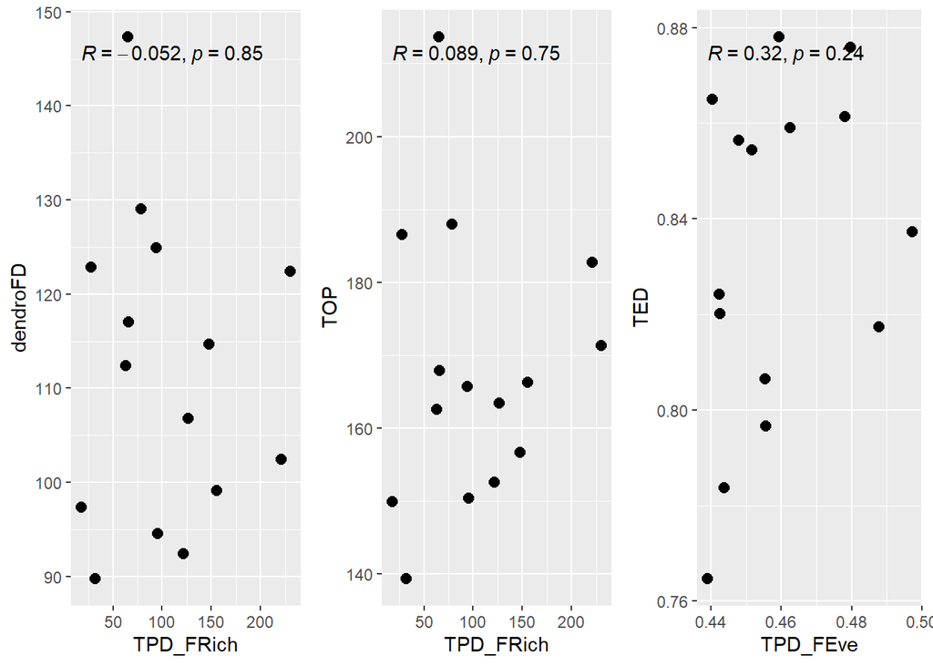

```r
TPD_df <- data.frame(TOP_TED, dendroFD, TPD_FRich = TPD_FD$communities$FRichness,
                     TPD_FEve = TPD_FD$communities$FEvenness,
                     TPD_FDiv = TPD_FD$communities$FDivergence)

p1 <- ggplot(TPD_df, aes(x = TPD_FRich, y = dendroFD)) +
  geom_point(size = 2.5) + stat_cor(method = "pearson")

p2 <- ggplot(TPD_df, aes(x = TPD_FRich, y = TOP)) +
  geom_point(size = 2.5) + stat_cor(method = "pearson")

p3 <- ggplot(TPD_df, aes(x = TPD_FEve, y = TED)) +
  geom_point(size = 2.5) + stat_cor(method = "pearson")

ggarrange(p1, p2, p3, nrow = 1, ncol = 3)
```

All these metrics are uncorrelated, likely because methods are inherently different. TPD use probability density functions to characterize species and use abundances to weight the relative contribution of species traits to a community. By contrast, the previous methods use raw individual values and do not account for species abundances.

## n-dimensional hypervolumes

n-dimensional hypervolumes are a set of techniques that describe a geometrical shape surrounding species (or individuals for our purpose) in functional trait space, largely resembling the idea of the Hutchinsonian niche. These shapes can be constructed through either non-parametric or parametric methods.

### Kernel-density hypervolumes

Kernel density hypervolumes are based on kernel density estimation to construct hypervolumes, and largely resemble the idea of the TPD framework.

```r
# Trait matrix of individuals
traits <- do.call(rbind, trait_matrix)[,-1]

# Community matrix at the individual level
traits$comm <- sort(rep(1:ncomms, nindxsp*nsp))
traits$sp_ind <- 1:nrow(traits)
Cind <- as.data.frame.matrix(table(traits$comm, traits$sp_ind))

# Build hypervolumes for each community. Due to the large amount of computation time required, I use only 10 random points per individual to simulate kernels, but should be increased to a minimum of 100 in practice for a good description of the underlying trait distribution.
hvlist <- kernel.build(comm = Cind, trait = traits, axes = 2, distance = "gower", method = "gaussian", abund = FALSE, samples.per.point = 10)
```

```
## Building hypervolume 1 of 15
## Building hypervolume 2 of 15
## Building hypervolume 3 of 15
## Building hypervolume 4 of 15
## Building hypervolume 5 of 15
## Building hypervolume 6 of 15
## Building hypervolume 7 of 15
## Building hypervolume 8 of 15
## Building hypervolume 9 of 15
## Building hypervolume 10 of 15
## Building hypervolume 11 of 15
## Building hypervolume 12 of 15
## Building hypervolume 13 of 15
## Building hypervolume 14 of 15
## Building hypervolume 15 of 15
```

```r
# Compute functional diversity metrics
hv_richness <- kernel.alpha(hvlist)
hv_regularity <- kernel.evenness(hvlist)
```

[output not shown]

[output cut: 125 more lines]

[output not shown]

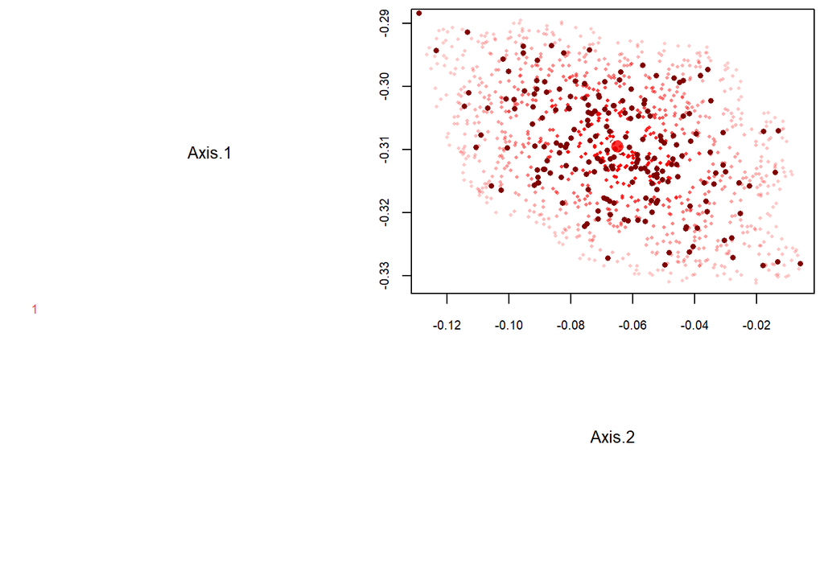

```r
hv_divergence <- kernel.dispersion(hvlist, func = "divergence")

# Some examples of hypervolumes (communities 1, 5, 10)
plot(hvlist[[1]], show.contour = FALSE)
```

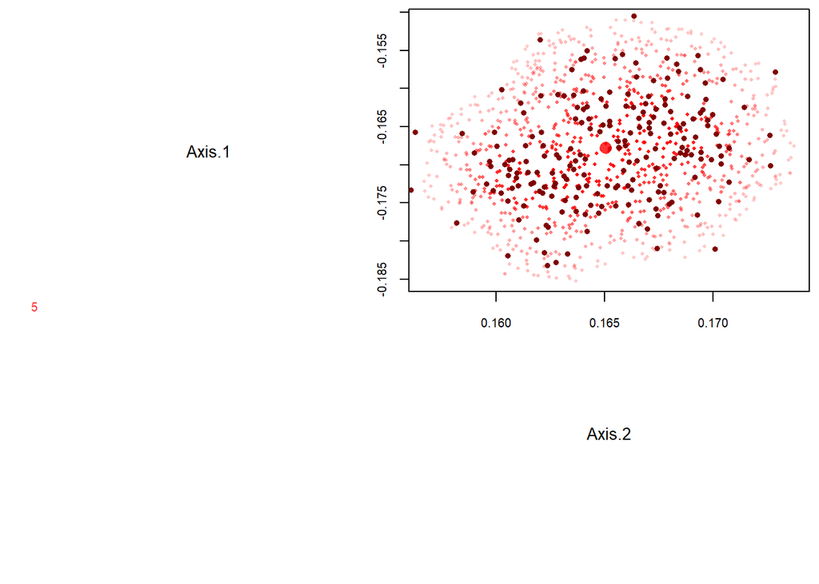

```r
plot(hvlist[[5]], show.contour = FALSE)
```

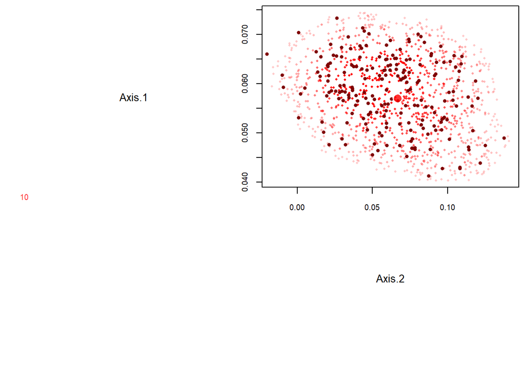

```r
plot(hvlist[[10]], show.contour = FALSE)
```

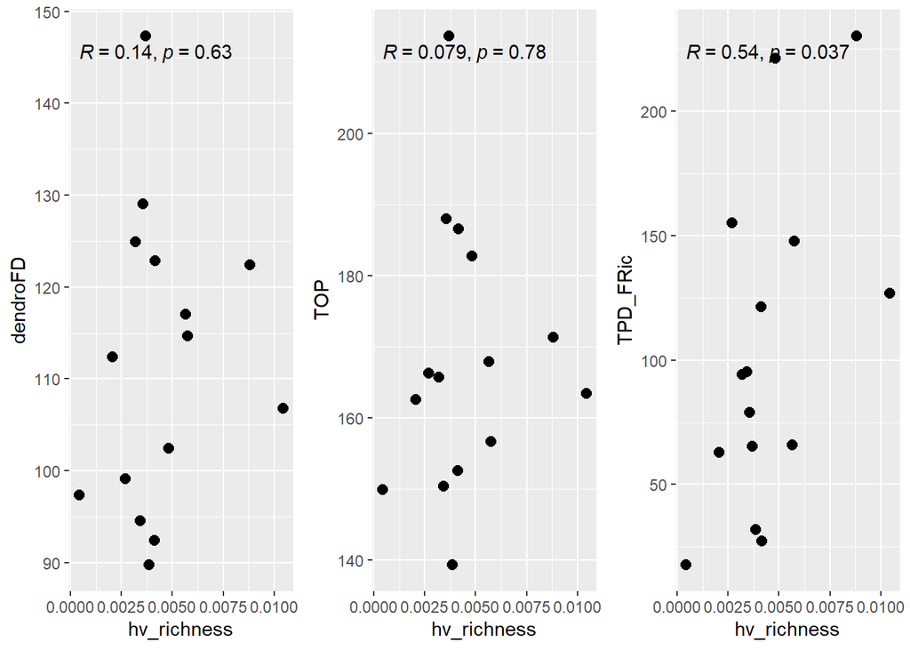

```r
kernel_df <- data.frame(hv_richness, hv_regularity, hv_divergence, TOP_TED, dendroFD, TPD_FRic =  TPD_FD$communities$FRichness,
                        TPD_FEve = TPD_FD$communities$FEvenness,
                        TPD_FDiv = TPD_FD$communities$FDivergence)

p1 <- ggplot(kernel_df, aes(x = hv_richness, y = dendroFD)) +
  geom_point(size = 2.5) + stat_cor(method = "pearson")

p2 <- ggplot(kernel_df, aes(x = hv_richness, y = TOP)) +
  geom_point(size = 2.5) + stat_cor(method = "pearson")

p3 <- ggplot(kernel_df, aes(x = hv_richness, y = TPD_FRic)) +
  geom_point(size = 2.5) + stat_cor(method = "pearson")

p4 <- ggplot(kernel_df, aes(x = hv_regularity, y = TED)) +
  geom_point(size = 2.5) + stat_cor(method = "pearson")

p5 <- ggplot(kernel_df, aes(x = hv_regularity, y = TPD_FEve)) +
  geom_point(size = 2.5) + stat_cor(method = "pearson")

ggarrange(p1, p2, p3, nrow = 1, ncol = 3)
```

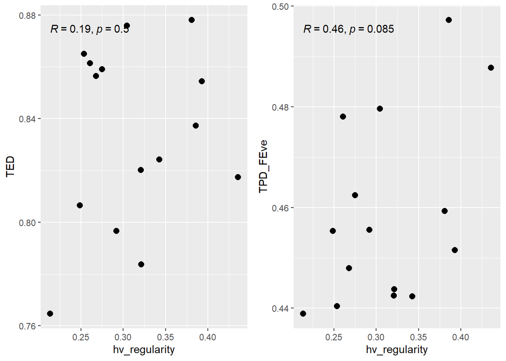

```r
ggarrange(p4, p5, nrow = 1, ncol = 2)
```

Hypervolume metrics are positively, although slightly, correlated to those above, because they work differently. However, as they are probabilistic in nature and conceptually similar, the highest correlation is found between kernel hypervolume and TPD functional richness.

### Multivariate normal hypervolumes

More recently, Lu et al. (2020) proposed to use multivariate normal distributions to delineate n-dimensional hypervolumes (termed ‘MVNH framework’) and describe the Hutchinsonian niche in terms that can be biologically interpreted. Moreover, this approach allows estimating the relative importance of niche size and distance driven dissimilarity between hypervolumes, and it is computationally faster than non-parametric methods.

```r
# Function to compute the determinant of the hypervolume based on a multivariate normal distribution (from https://github.com/lvmuyang/MVNH)
MVNH_det <- function(data=NULL,cov=NULL,var.names=NULL,cov.matrix=F,log=F){
  # fetch names from the data or covariance matrix
  if(!cov.matrix){
    if(is.null(var.names)){
      if(is.matrix(data) & !is.null(colnames(data))) var.name = colnames(data)
      if(is.matrix(data) & is.null(colnames(data))) var.name = paste0("variable",1:ncol(data))
      if(is.data.frame(data)) var.name = names(data)
    } else {
      var.name = var.names}
  } else{
    if(is.null(var.names)){
      if(is.matrix(cov) & !is.null(colnames(cov))) var.name = colnames(cov)
      if(is.matrix(cov) & is.null(colnames(cov))) var.name = paste0("variable",1:ncol(cov))
      if(is.data.frame(cov)) var.name = names(cov)
    } else {
      var.name = var.names}
  }

  if(cov.matrix){
    COV = cov
  } else {
    COV = cov(data)
  }
  s = diag(COV)
  rho = det(COV)/prod(s)
  det = c(det(COV),s,rho)
  names(det) = c("total",var.name,"cor")
  if(log) {
    return(log(det))}
  else{
    return(det)
  }
}

# Compute MVNH for every community
MVNH_comms <- data.frame(matrix(NA, nrow = ncomms, ncol = ntraits + 2))
for(i in 1:ncomms){
  ztrait_matrix <- as.data.frame(scale(trait_matrix[[i]][, -1]))
  MVNH_comms[i,] <- MVNH_det(ztrait_matrix)
}
colnames(MVNH_comms)[1] <- "determinant"
colnames(MVNH_comms)[ncol(MVNH_comms)] <- "correlation"
colnames(MVNH_comms)[c(2:(ncol(MVNH_comms)-1))] <- colnames(traits)
```

Since the determinant of the hypervolume is a measure of niche size, then this metric only reflects functional richness. Again, we can compare this metric with previous indices.

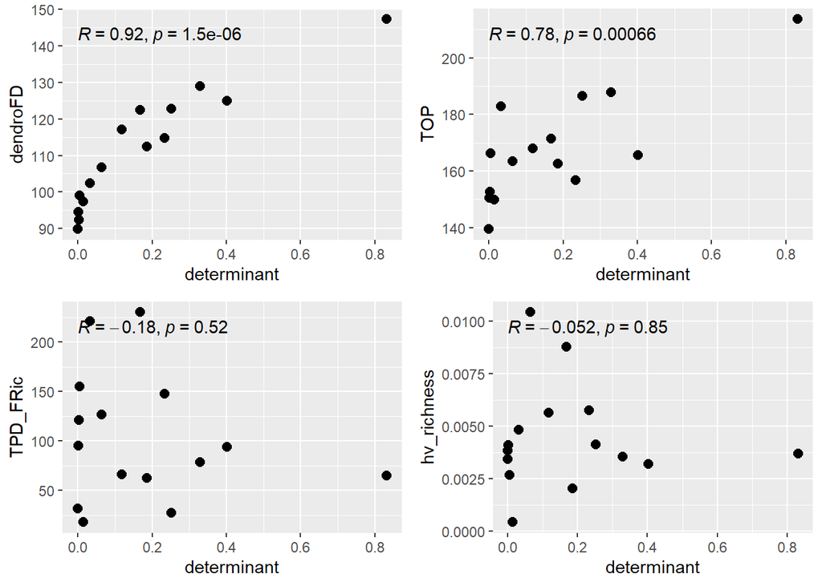

```r
mvnh_df <- cbind(MVNH_comms, dendroFD, TOP = TOP_TED$TOP, hv_richness,
                 TPD_FRic =  TPD_FD$communities$FRichness)
p1 <- ggplot(data = mvnh_df, aes(x = determinant, y = dendroFD)) +
  geom_point(size = 2.5) + stat_cor(method = "pearson")

p2 <- ggplot(data = mvnh_df, aes(x = determinant, y = TOP)) +
  geom_point(size = 2.5) + stat_cor(method = "pearson")

p3 <- ggplot(data = mvnh_df, aes(x = determinant, y = TPD_FRic)) +
  geom_point(size = 2.5) + stat_cor(method = "pearson")

p4 <- ggplot(data = mvnh_df, aes(x = determinant, y = hv_richness)) +
  geom_point(size = 2.5) + stat_cor(method = "pearson")

ggarrange(p1, p2, p3, p4, nrow = 2, ncol = 2)
```

As expected, the determinant of the hypervolume is positively correlated with other functional richness metrics. Yet, functional richness based on probabilistic hypervolumes is far less correlated with the MVNH approach. This is expected because these largely depend on the irregular shapes built around the cloud of points that can contain holes, which could be certainly very different to an hyper-ellipsoid as the MVNH approach assume.